# Ramandeep Kaur 8976849

# Lab 7 - Performance Metrics for Classification

The goal of this lab is to Evaluate a model for MNIST classification.

# Introduction (Wikipedia)

Mnist (Modified National Institute of Standards and Technology database) is a set of database of handwritten digits that used for training various Image processing system. The database is also widely use for training and testing in the area of Machine Learning.

Resources:

Classnotebook: [Performance Matrics for Classification](https://github.com/CSCN8010/CSCN8010/blob/main/class_notebooks/classification-performance-metrics/performance_metrics_for_classification.ipynb)

Kaggle: [MNIST Classification](https://www.kaggle.com/code/blurredmachine/mnist-classification-eda-pca-cnn-99-7-score)

```python
import numpy as np
import pandas as pd
from sklearn.model_selection import train_test_split

# plotting modules
from matplotlib import pyplot as plt
import matplotlib.patches as patches  # for curved arrows
import seaborn as sns

# The web source of the MNIST dataset that we will work with
from sklearn.datasets import fetch_openml

# The classifiers we will use in this notebook
from sklearn.linear_model import SGDClassifier

# cross validation functions
from sklearn.model_selection import cross_validate, cross_val_predict

# performance metrics
from sklearn.metrics import confusion_matrix, precision_score, recall_score, f1_score, precision_recall_curve, roc_curve, roc_auc_score,  classification_report, accuracy_score
```

Download the MNIST data

Load the data from [openml.org](https://openml.org/) using the function `sklearn.datasets.fetch_openml`

```python
mnist = fetch_openml('mnist_784', as_frame=False, parser='auto')
```

## **Exploring the Data**

```python
print(mnist.DESCR)
```

```
**Author**: Yann LeCun, Corinna Cortes, Christopher J.C. Burges
**Source**: [MNIST Website](http://yann.lecun.com/exdb/mnist/) - Date unknown
**Please cite**:

The MNIST database of handwritten digits with 784 features, raw data available at: http://yann.lecun.com/exdb/mnist/. It can be split in a training set of the first 60,000 examples, and a test set of 10,000 examples

It is a subset of a larger set available from NIST. The digits have been size-normalized and centered in a fixed-size image. It is a good database for people who want to try learning techniques and pattern recognition methods on real-world data while spending minimal efforts on preprocessing and for…

With some classification methods (particularly template-based methods, such as SVM and K-nearest neighbors), the error rate improves when the digits are centered by bounding box rather than center of mass. If you do this kind of pre-processing, you should report it in your publications. The MNIST da…

The MNIST training set is composed of 30,000 patterns from SD-3 and 30,000 patterns from SD-1. Our test set was composed of 5,000 patterns from SD-3 and 5,000 patterns from SD-1. The 60,000 pattern training set contained examples from approximately 250 writers. We made sure that the sets of writers …

Downloaded from openml.org.
```

```python
# Type of the mnist dataset
type(mnist)
```

```
sklearn.utils._bunch.Bunch
```

```python
# Keys in mnist dataset
mnist.keys()
```

```
dict_keys(['data', 'target', 'frame', 'categories', 'feature_names', 'target_names', 'DESCR', 'details', 'url'])
```

```python
# Shape of the mnist data array
mnist.data.shape
```

```
(70000, 784)
```

```python
mnist.feature_names

# Array representing the pixel values of the first image
mnist.data[0]

# Shape of the target array: (70000,) indicating the labels for each image
mnist.target.shape
```

```
(70000,)
```

```python
# Check for null values
data = pd.DataFrame(mnist.data)
is_null = data.isnull().sum()
print(is_null)

data.describe()
```

```
0      0
1      0
2      0
3      0
4      0
      ..
779    0
780    0
781    0
782    0
783    0
Length: 784, dtype: int64
```

|  | 0 | 1 | 2 | 3 | 4 | 5 | 6 | 7 | 8 | 9 | ... | 774 | 775 | 776 | 777 | 778 | 779 | 780 | 781 | 782 | 783 |
| --- | --- | --- | --- | --- | --- | --- | --- | --- | --- | --- | --- | --- | --- | --- | --- | --- | --- | --- | --- | --- | --- |
| count | 70000.0 | 70000.0 | 70000.0 | 70000.0 | 70000.0 | 70000.0 | 70000.0 | 70000.0 | 70000.0 | 70000.0 | ... | 70000.000000 | 70000.000000 | 70000.000000 | 70000.000000 | 70000.000000 | 70000.000000 | 70000.0 | 70000.0 | 70000.0 | 70000.0 |
| mean | 0.0 | 0.0 | 0.0 | 0.0 | 0.0 | 0.0 | 0.0 | 0.0 | 0.0 | 0.0 | ... | 0.197414 | 0.099543 | 0.046629 | 0.016614 | 0.012957 | 0.001714 | 0.0 | 0.0 | 0.0 | 0.0 |
| std | 0.0 | 0.0 | 0.0 | 0.0 | 0.0 | 0.0 | 0.0 | 0.0 | 0.0 | 0.0 | ... | 5.991206 | 4.256304 | 2.783732 | 1.561822 | 1.553796 | 0.320889 | 0.0 | 0.0 | 0.0 | 0.0 |
| min | 0.0 | 0.0 | 0.0 | 0.0 | 0.0 | 0.0 | 0.0 | 0.0 | 0.0 | 0.0 | ... | 0.000000 | 0.000000 | 0.000000 | 0.000000 | 0.000000 | 0.000000 | 0.0 | 0.0 | 0.0 | 0.0 |
| 25% | 0.0 | 0.0 | 0.0 | 0.0 | 0.0 | 0.0 | 0.0 | 0.0 | 0.0 | 0.0 | ... | 0.000000 | 0.000000 | 0.000000 | 0.000000 | 0.000000 | 0.000000 | 0.0 | 0.0 | 0.0 | 0.0 |
| 50% | 0.0 | 0.0 | 0.0 | 0.0 | 0.0 | 0.0 | 0.0 | 0.0 | 0.0 | 0.0 | ... | 0.000000 | 0.000000 | 0.000000 | 0.000000 | 0.000000 | 0.000000 | 0.0 | 0.0 | 0.0 | 0.0 |
| 75% | 0.0 | 0.0 | 0.0 | 0.0 | 0.0 | 0.0 | 0.0 | 0.0 | 0.0 | 0.0 | ... | 0.000000 | 0.000000 | 0.000000 | 0.000000 | 0.000000 | 0.000000 | 0.0 | 0.0 | 0.0 | 0.0 |
| max | 0.0 | 0.0 | 0.0 | 0.0 | 0.0 | 0.0 | 0.0 | 0.0 | 0.0 | 0.0 | ... | 254.000000 | 254.000000 | 253.000000 | 253.000000 | 254.000000 | 62.000000 | 0.0 | 0.0 | 0.0 | 0.0 |

8 rows × 784 columns

Kaggle : [Reference](https://www.kaggle.com/code/kanikaw/mnist-nn-from-scratch?scriptVersionId=164122350&cellId=8)

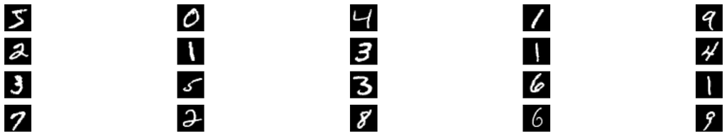

```python
import matplotlib.pyplot as plt

plt.figure(figsize=(20, 4))
for i in range(20):
    plt.subplot(5, 5, i + 1)  # Change 1, 20 to 4, 4 for a 4x4 grid
    plt.imshow(mnist.data[i].reshape(28, 28), cmap='gray')
    plt.axis('off')

plt.tight_layout()  # Add tight_layout for better spacing
plt.show()
```

- From the visualization we can see that the same digits are hand written in different ways.
- Some of the digits are not perfectly formed and have varying thickness and curvature.

### **Visualize first 10 samples from each class**

Kaggle : [Reference](https://www.kaggle.com/code/fold10/exploring-mnist?scriptVersionId=129644281&cellId=4)

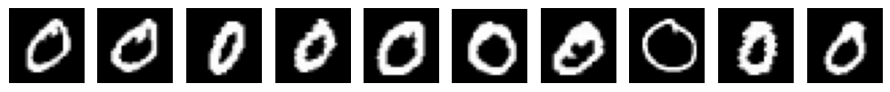

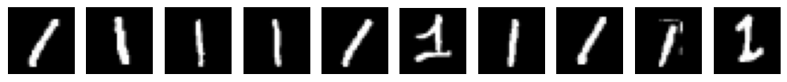

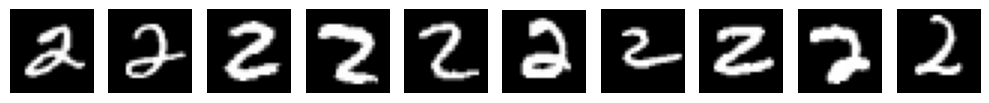

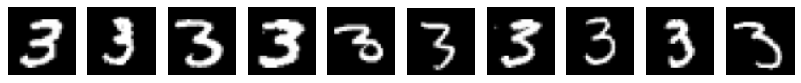

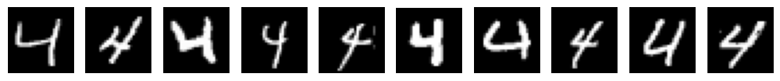

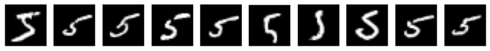

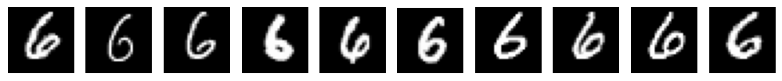

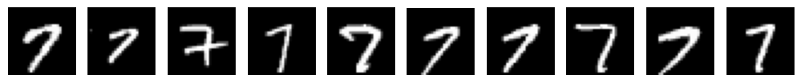

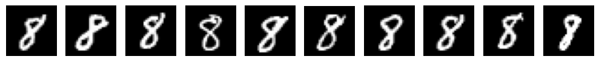

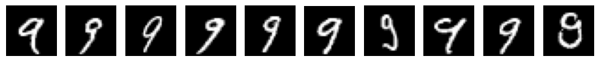

```python
classes = np.unique(mnist.target)

# For each class
for cls in classes:
    # Initialize plot with better spacing
    fig, axes = plt.subplots(1, 10, figsize=(10, 3))

    # Get first 10 samples of this class
    samples = mnist.data[mnist.target == cls][:10]

    # For each sample
    for i, sample in enumerate(samples):
        # Plot sample
        img = sample.reshape(28, 28)
        axes[i].imshow(img, cmap='gray')
        axes[i].axis("off")

    # Add tight layout for better spacing
    plt.tight_layout()

    # Show plot
    plt.show()
```

# Check Distribution of class

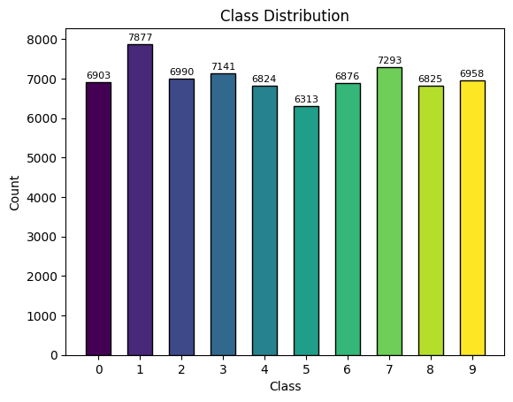

```python
class_counts = np.bincount(mnist.target.astype(int))

# Set a color for the bars
bar_colors = plt.cm.viridis(np.linspace(0, 1, len(class_counts)))

plt.bar(np.arange(10), class_counts, color=bar_colors, width=0.6, edgecolor='black')
plt.xlabel('Class')
plt.ylabel('Count')
plt.title('Class Distribution')
plt.xticks(np.arange(10), np.arange(10))  # Set x-axis ticks explicitly

# Adding text annotations on top of the bars
for i, count in enumerate(class_counts):
    plt.text(i, count + 50, str(count), ha='center', va='bottom', fontsize=8)

plt.show()
```

Observations:

Digit '1' exhibits the highest count among the classes. Digit '5' displays the lowest count in the distribution. Overall, the plot illustrates a well-balanced distribution of classes in the MNIST dataset.

### **Explore pixel intensity distributions for a sample image**

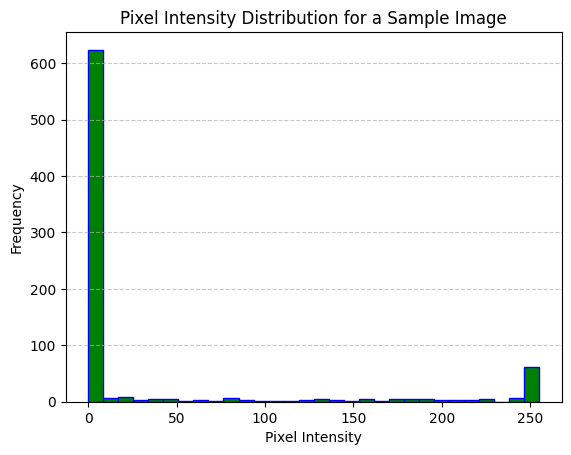

```python
# Adjust the number of bins and color

plt.hist(mnist.data[0], bins=30, color='green', edgecolor='blue')
plt.xlabel('Pixel Intensity')
plt.ylabel('Frequency')
plt.title('Pixel Intensity Distribution for a Sample Image')

# Add grid lines on the y-axis
plt.grid(axis='y', linestyle='--', alpha=0.7)
plt.show()
```

# Choose Number of Classes

```python
# Choose 3 classes from the MNIST dataset
selected_classes = ['0', '3', '5', '7', '9']
selected_indices = np.isin(mnist.target, selected_classes)
X_selected = mnist.data[selected_indices]
y_selected = mnist.target[selected_indices]
```

```python
# Ensure Consistency between Target and Data Entities

alignment_check = X_selected.shape, y_selected.shape
alignment_check
```

```
((34608, 784), (34608,))
```

## Split dataset to train-validation-test

```python
train_ratio = 0.70
test_ratio = 0.15
validation_ratio = 0.15

X_train, X_test, y_train, y_test = train_test_split(X_selected, y_selected, test_size=test_ratio, random_state=42)
X_train, X_val, y_train, y_val = train_test_split(X_train, y_train, test_size=validation_ratio/(train_ratio+test_ratio), random_state=42)
```

```python
# Display shapes of the training, testing, and validation sets
train_test_val_shapes = X_train.shape, X_test.shape, X_val.shape
train_test_val_shapes
```

```
((24224, 784), (5192, 784), (5192, 784))
```

```python
#  SGDClassifier

sgd_clf = SGDClassifier(random_state=42)
sgd_clf.fit(X_train, y_train)
```

```
SGDClassifier(random_state=42)
```

```python
y_val_pred = sgd_clf.predict(X_val)
```

## Evaluation of Model

Kaggle : [Reference](https://www.kaggle.com/code/iqraasghar/handwritten-digit-detection-mnist-dataset?scriptVersionId=39355645&cellId=12)

```python
def print_validation_report(y_true, y_pred):
    print("Classification Report")
    print(classification_report(y_true, y_pred))
    accuracy = accuracy_score(y_true, y_pred)
    print("Accuracy of Validation Data: "+ str(accuracy))

    return accuracy
```

### Classification Report

Accuracy Precision recall and F1 for each class

```python
acc_sgd  = print_validation_report(y_val, y_val_pred)
```

```
Classification Report
              precision    recall  f1-score   support

           0       0.95      0.98      0.97      1022
           3       0.94      0.93      0.93      1067
           5       0.93      0.91      0.92       982
           7       0.97      0.88      0.93      1086
           9       0.87      0.94      0.91      1035

    accuracy                           0.93      5192
   macro avg       0.93      0.93      0.93      5192
weighted avg       0.93      0.93      0.93      5192

Accuracy of Validation Data: 0.9298921417565486
```

# Confusion metric

Kaggle : [Reference](https://www.kaggle.com/code/iqraasghar/handwritten-digit-detection-mnist-dataset?scriptVersionId=39355645&cellId=13)

```python
cm = confusion_matrix(y_val, y_val_pred)
cm
```

```
array([[1005,    2,    9,    1,    5],
       [  11,  988,   47,    7,   14],
       [  23,   33,  897,    2,   27],
       [   6,   14,    6,  961,   99],
       [  12,   19,    8,   19,  977]], dtype=int64)
```

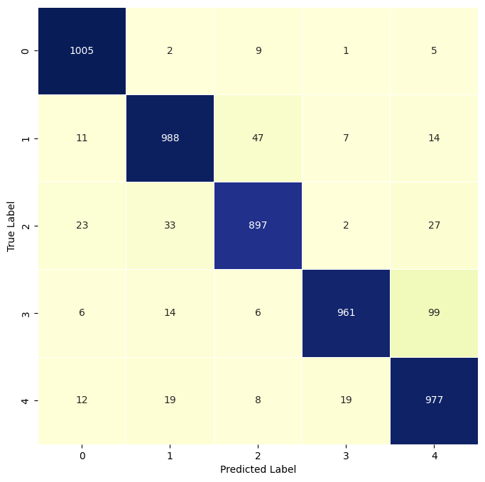

```python
def plot_confusion_matrix(y_true, y_pred):
    confusion_mtx = confusion_matrix(y_true, y_pred)
    fig, ax = plt.subplots(figsize=(8, 8))
    sns.heatmap(confusion_mtx, annot=True, fmt='d', linewidths=0.5, cmap='YlGnBu', cbar=False, ax=ax)
    plt.ylabel('True Label')
    plt.xlabel('Predicted Label')

plot_confusion_matrix(y_val, y_val_pred)
```

### Precision-Recall Curve

```python
y_val_scores = cross_val_predict(sgd_clf, X_val, y_val, cv=3, method="decision_function")


chosen_class = '0'
unique_classes = np.unique(y_val)
chosen_class_index = np.where(unique_classes == chosen_class)[0][0]
y_val_binary = (y_val == chosen_class).astype(int)
precisions, recalls, thresholds = precision_recall_curve(y_val_binary, y_val_scores[:, chosen_class_index])

print(precisions.shape)
print(recalls.shape)
print(thresholds.shape)
```

```
(5193,)
(5193,)
(5192,)
```

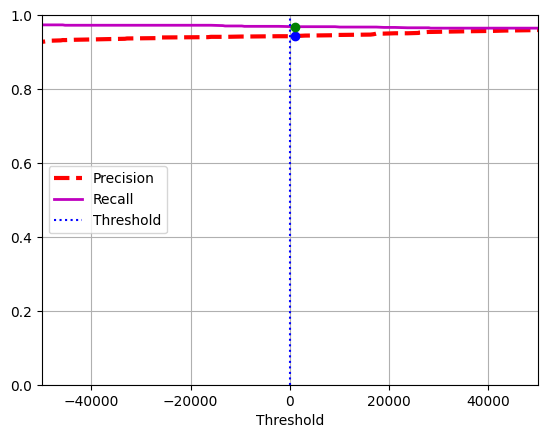

```python
threshold = 0
plt.plot(thresholds, precisions[:-1], "r--", label="Precision", linewidth=3)
plt.plot(thresholds, recalls[:-1], "m-", label="Recall", linewidth=2)
plt.axvline(x=threshold, color="b", linestyle="dotted", label="Threshold")
idx = (thresholds >= threshold).argmax()  # first index ≥ threshold
plt.plot(thresholds[idx], precisions[idx], "bo")
plt.plot(thresholds[idx], recalls[idx], "go")
plt.axis([-50000, 50000, 0, 1])
plt.grid()
plt.xlabel("Threshold")
plt.legend(loc="center left")
plt.show()
```

Insights

-Line Plots:

Plots precision (red dashed line) and recall (magenta solid line) against different threshold values.

-Threshold Line:

-Highlighted Point:

Marks a specific threshold point on the precision (blue marker) and recall (green marker) curves.

-Axes and Display:

Sets x-axis limits from -50000 to 50000 and y-axis limits from 0 to 1. Adds grid lines, labels x-axis as "Threshold."

-Legend:

Adds a legend at the center-left position.

-Purpose:

Visualizes the relationship between precision and recall at different threshold values, emphasizing a specific threshold. Common in binary classification analysis.

## **Increase precision and recall for chosen class**

```python
# Adjust threshold to increase precision
threshold_precision = 0.8

# Convert probabilities to predicted class labels based on the new threshold
predicted_class_labels = (y_val_scores[:, int(chosen_class)] > threshold_precision).astype(int)

# Calculate precision after adjusting the threshold
precision_after_adjustment = precision_score(y_val_binary, predicted_class_labels)
print("Precision after adjustment:", precision_after_adjustment)
```

```
Precision after adjustment: 0.9428571428571428
```

```python
# Adjust threshold to increase recall
threshold_recall = 0.1

# Convert probabilities to predicted class labels based on the new threshold
predicted_class_labels = (y_val_scores[:, chosen_class_index] > threshold_recall).astype(int)

# Calculate recall after adjusting the threshold
recall_after_adjustment = recall_score(y_val_binary, predicted_class_labels)
print("Recall after adjustment:", recall_after_adjustment)
```

```
Recall after adjustment: 0.9686888454011742
```

# Evaluate the model accuracy on the test set

```python
# Predict the labels for the test set using the SGD classifier
y_test_pred = sgd_clf.predict(X_test)

# Evaluate and print the validation report for the test set
acc_sgd = print_validation_report(y_test, y_test_pred)
```

```
Classification Report
              precision    recall  f1-score   support

           0       0.94      0.99      0.96      1018
           3       0.92      0.93      0.93      1064
           5       0.92      0.90      0.91       936
           7       0.98      0.89      0.93      1070
           9       0.89      0.94      0.92      1104

    accuracy                           0.93      5192
   macro avg       0.93      0.93      0.93      5192
weighted avg       0.93      0.93      0.93      5192

Accuracy of Validation Data: 0.9293143297380585
```

# Conclusion

In summary, the model demonstrates strong performance when evaluated on the test dataset, showcasing high levels of accuracy, precision, recall, and F1-score.

The F1-score, which serves as a comprehensive metric considering both precision and recall, is consistently high across all classes. This suggests a well-balanced performance in terms of accurately identifying positive instances and minimizing false positives.

In conclusion, the model's robust performance metrics underscore its effectiveness in handling the test data and make it a reliable tool for the given task.